# TAR-FAMILY

Flávio Macaúbas Torres Filho e José Carlos Claudino Filho

31/05/2022

# Threshold AR - TAR

Existem duas possíveis quebras em uma série: média ou variância. Neste ensaio, estamos interessados em série com diferentes médias e como utilizar os modelas da famílias TAR.

Para o caso de séries com quebra na variância, os modelos recomendados são da família ARCH, direcionados para modelar problemas de heterocedasticidade.

> Em uma longa viagem de automóvel para um novo local, você pode seguir um atlas de estrada […] Para a maioria das viagens, essa aproximação linear é extremamente útil. Para outros tipos de viagens, a suposição de lieanridade é claramente inadequada. Seria desastroso para a NASA usar um mapa plano da Terra para planejar a trajetória de um lançamento de foguete. [Enders, 2008]

**Quebra na média**

Para melhor entendermos possíveis quebras na média de uma série, vamos partir de um processo estocástico em tempo contínuo definido como *Brownian Bridge*, dado por:

$$B(\frac{t}{T}) =
\frac{1}{\sqrt{T}}[\sum^{t}_{s = 1}(\epsilon_{s} -
\bar{\epsilon})]$$

Começando de t = 0 e terminando em t = 1, onde $\epsilon$ é i.i.d mas não necessariamente normal, e $\bar{\epsilon}$ é a média do conjunto completo de T observações.

Vamos supor que, em vez de uma média fixa, haja uma na parte inicial da amostra $(\bar{X_{1}})$ e outra média maior $(\bar{X_{2}})$ para outra amostra de dados. Assim, ao subtrairmos $(\bar{X_{2}})$ da amostra completa teremos que os valores inicias irão assumir valores negativos e os demais tendem a voltar a zero.

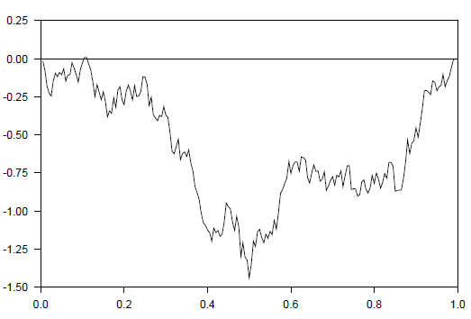

Besarria (2022)

Neste caso, queremos verificar as seguintes hipóteses:

$$\left\{
\begin{matrix}
H_{0} \;\;\;\; \bar{X_{1}} = \bar{X_{2}}
\\
H_{1} \;\;\;\; \bar{X_{1}} \neq \bar{X_{2}}
\end{matrix}
\right.$$
Para o caso da Brownian Bridge, rejeitamos a hipótese nula de médias iguais. Se verificarmos essa hipótese, os modelos da família TAR são os mais adequados para lidar com o problema.

## Processos não lineares

O sucesso dos modelos ARMA Gaussianos, deve-se:

- Simplicidade: as equações às diferenças finitas são fáceis de tratar;
- O modelo ARMA Gaussiano é compeltamente caracterizado pela média, variância e pelas autocorrelações;
- A teoria está completamente desenvolvida: todas as principais questões relacionadas com a estimação, inferência e previsão estão resolvidas;
- Apesar da simplicidade são úteis na análise de previsão de um grande número de séries econômicas.

Todavia, os modelos não são apropriados quando:

- **Os dados exibem súbitas alterações em períodos irregulares;**
- **Não são apropriados para dados que exibam forte assimetria ou curtose.**

## O que são modelos não lineares

Considere um seguinte modelo:

$$y_{t} = \mu_{t} + \epsilon_{t} \; / \; \epsilon_{t} = \sigma_{t}u_{t}$$
Em que,

$\epsilon_{t}$ é um ruído branco;

$\mu_{t} = g(y_{t-1}, \dots, y_{t-p} ; \epsilon_{t-1}, \dots , \epsilon_{t-q})$ é a média condicional de $y_{t}$;

$\sigma^{2}_{t} = h(y_{t-1}, \dots, y_{t-\tilde{p}}; \epsilon_{t-1}, \dots , \epsilon_{t-\tilde{q}}) > 0$ é a variância condicional de $y_{t}$.

Naturalmente, podemos concluir que:

- A série será não linear na média se g é uma função não linear de seus argumentos.
- A série senão linear na variâcnia se $\sigma_{t}$ é não constante ao longo do tempo.

## Apresentando o modelo TAR (Threshold autoregressive)

Neste caso, temos dois regimes, dependendo se $y_{t-d}$ é maior ou menor que o limiar $\gamma$.

**Modelos de quebras estruturais podem ser incluídos nessa classe de modelos e um dos objetivos é estimar o ponto de mudança do regime**

## Instalação e Imports

```r
#install.packages("tidyverse")
#install.packages("skimr")
#install.packages("janitor")
#install.packages('seasonal')
#install.packages('gridExtra')
#install.packages('imputeTS')
#install.packages('tsoutliers')
#install.packages('forecast')
#install.packages('MASS')
#install.packages('tseries')
#install.packages("urca")
#install.packages("strucchange")
#install.packages("lubridate")
#install.packages("nonlinearTseries")
#install.packages("lmtest")
#install.packages("locfit")
#install.packages("TSA")
#install.packages("tsDyn")
#install.packages("TAR")
```

```r
# Pacote para análise de dado
library(tidyverse)

# Pacotes para limpeza e sumarização de dados
library(skimr)
library(janitor)
library(imputeTS)
library(tsoutliers)

# Dataviz
library(ggplot2)
library(scales)
library(gridExtra)

# Manipulação de datas
library(lubridate)

# Série Temporal
library(seasonal)
library(stats)
library(forecast)
library(MASS) # BoxCox

# Testes de estacionariedade
library(tseries) # ADF, PP e KPSS
library(urca) # ERS - Zivot Andrews


# Quebras estruturais
library(strucchange) # Teste de Chow
source("C:/Users/Macaubas/Desktop/Mestrado/Cadeiras/Series/Projeto/Series Temporal/Markdown/quebra-estrutural-lee-stra.R") # Teste Lee Stra

# Não linearidade
library(nonlinearTseries)
library(lmtest)

# Modelo TAR
library(locfit)
library(TSA)
library(tsDyn)
library(TAR)

# Configuração número científico
options(scipen = 999)
```

### Leitura dos dados

```r
# Data loading
petrol = read.csv("C:/Users/Macaubas/Desktop/Mestrado/Cadeiras/Series/Projeto/Series Temporal/Dados/MCOILBRENTEU.csv") %>%
  as_tibble()

# Ajuste do nome das colunas para minúsculo
petrol = petrol %>%
  rename_with(tolower)


# Criando serie logaritmica e os respectivos lags
petrol = petrol %>%
  mutate(date = ymd(date)) %>%
  mutate(log_petrol = log(mcoilbrenteu),
         petrol_lag = lag(mcoilbrenteu,1),
         petrol_lag_log = lag(log_petrol,1))

# Visualizando os dados
petrol
```

```
## # A tibble: 419 × 5
##    date       mcoilbrenteu log_petrol petrol_lag petrol_lag_log
##    <date>            <dbl>      <dbl>      <dbl>          <dbl>
##  1 1987-05-01         18.6       2.92       NA            NA
##  2 1987-06-01         18.9       2.94       18.6           2.92
##  3 1987-07-01         19.9       2.99       18.9           2.94
##  4 1987-08-01         19.0       2.94       19.9           2.99
##  5 1987-09-01         18.3       2.91       19.0           2.94
##  6 1987-10-01         18.8       2.93       18.3           2.91
##  7 1987-11-01         17.8       2.88       18.8           2.93
##  8 1987-12-01         17.0       2.84       17.8           2.88
##  9 1988-01-01         16.8       2.82       17.0           2.84
## 10 1988-02-01         15.7       2.76       16.8           2.82
## # … with 409 more rows
```

## Transformando em série

```r
serie_petrol = ts(start = c(1987,05,01),
                    petrol$mcoilbrenteu,
                    freq = 12)

head(serie_petrol, 20)
```

```
##        Jan   Feb   Mar   Apr   May   Jun   Jul   Aug   Sep   Oct   Nov   Dec
## 1987                         18.58 18.86 19.86 18.98 18.31 18.76 17.78 17.05
## 1988 16.75 15.73 14.73 16.60 16.31 15.54 14.91 14.89 13.18 12.41 13.02 15.31
```

## Testando Linearidade da série

```r
set.seed(1)
nonlinearityTest(serie_petrol)
```

```
##       ** Teraesvirta's neural network test  **
##       Null hypothesis: Linearity in "mean"
##       X-squared =  5.878553  df =  2  p-value =  0.052904
##
##       ** White neural network test  **
##       Null hypothesis: Linearity in "mean"
##       X-squared =  2.883889  df =  2  p-value =  0.2364675
##
##       ** Keenan's one-degree test for nonlinearity  **
##       Null hypothesis: The time series follows some AR process
##       F-stat =  3.49283  p-value =  0.06234273
##
##       ** McLeod-Li test  **
##       Null hypothesis: The time series follows some ARIMA process
##       Maximum p-value =  0
##
##       ** Tsay's Test for nonlinearity **
##       Null hypothesis: The time series follows some AR process
##       F-stat =  7.982943  p-value =  0.00003487911
##
##       ** Likelihood ratio test for threshold nonlinearity **
##       Null hypothesis: The time series follows some AR process
##       Alternativce hypothesis: The time series follows some TAR process
##       X-squared =  17.16564  p-value =  0.01192038
```

```
## $Terasvirta
##
##  Teraesvirta Neural Network Test
##
## data:  ts(time.series)
## X-squared = 5.8786, df = 2, p-value = 0.0529
##
##
## $White
##
##  White Neural Network Test
##
## data:  ts(time.series)
## X-squared = 2.8839, df = 2, p-value = 0.2365
##
##
## $Keenan
## $Keenan$test.stat
## [1] 3.49283
##
## $Keenan$df1
## [1] 1
##
## $Keenan$df2
## [1] 413
##
## $Keenan$p.value
## [1] 0.06234273
##
## $Keenan$order
## [1] 2
##
##
## $McLeodLi
## $McLeodLi$p.values
##  [1] 0 0 0 0 0 0 0 0 0 0 0 0 0 0 0 0 0 0 0 0 0 0 0 0 0 0
##
##
## $Tsay
## $Tsay$test.stat
## [1] 7.982943
##
## $Tsay$p.value
## [1] 0.00003487911
##
## $Tsay$order
## [1] 2
##
##
## $TarTest
## $TarTest$percentiles
## [1] 24.94005 75.05995
##
## $TarTest$test.statistic
## [1] 17.16564
##
## $TarTest$p.value
## [1] 0.01192038
```

Vamos fragmentar esta análise por cada resultado:

De todos os teste de não-linearidade performados, o Likelihood Ratio apresenta uma hipótese alternativa bem definida. **Indicando que a série segue algum processo TAR**.

Por sua vez, o teste de Teraesvirta falha em rejeitar a linearidade, sugerindo que não há especificação LSTAR para o modelo.

## Estimando modelos

### SETAR

O modelo setar é um caso particular do modelo TAR, onde a série é função dela mesmo defasada. Estamos interessados em de captar 2 regimes diferentes para nossa série. Em outras palavras, estamos interessados em encontrar apenas um $\gamma$ para ajustar a modelagem. Consequentemente, iremos utilizar o resultado do teste de Zivot-Andrews do exercício passado.

A partir da quebra-estrutural quando período igual a 326 - 01/06/2014 (DD/MM/YYYY)

```r
petrol %>% slice(326)
```

```
## # A tibble: 1 × 5
##   date       mcoilbrenteu log_petrol petrol_lag petrol_lag_log
##   <date>            <dbl>      <dbl>      <dbl>          <dbl>
## 1 2014-06-01         112.       4.72       110.           4.70
```

Assim, podemos prosseguir com a estimação do regime levando em consideração o critério de informação AIC para seleção das ordens e delay.

```r
thd = 326/419*100

tar_aic = function(q_max, p_max, d, thd, serie, trans = 'no', est_thd = T){

  ordens = matrix(ncol = 3, nrow = 3)

  if (est_thd){

    for (p in seq(1,3, by = 1)){
      for (q in seq(1,3,by=1)){
        tar = TSA::tar(serie,
                   p1 = p,
                   p2 = q,
                   d = d,
                   a = 0.1,
                   transform = trans,
                   b = 0.9)

        ordens[p,q] = tar$AIC
      }
  }


  }else{

    for (p in seq(1,3, by = 1)){
      for (q in seq(1,3,by=1)){
        tar = TSA::tar(serie,
                   p1 = p,
                   p2 = q,
                   d = d,
                   a = 0.1,
                   b = 0.9,
                   estimate.thd = F,
                   transform = trans,
                   threshold = thd)

        ordens[p,q] = tar$AIC
      }
  }

  }


  return(ordens)
}

ordens_0 = tar_aic(3,3,0, thd = thd, serie_petrol, est_thd = F)
ordens_1 = tar_aic(3,3,1, thd = thd, serie_petrol, est_thd = F)
ordens_2 = tar_aic(3,3,2, thd = thd, serie_petrol, est_thd = F)
ordens_3 = tar_aic(3,3,3, thd = thd, serie_petrol, est_thd = F)
```

Verificando ordens:

```r
ordens_0
```

```
##      [,1] [,2] [,3]
## [1,] 2466 2443 2439
## [2,] 2418 2400 2396
## [3,] 2414 2396 2396
```

```r
ordens_1
```

```
##      [,1] [,2] [,3]
## [1,] 2446 2418 2414
## [2,] 2412 2389 2384
## [3,] 2407 2384 2384
```

```r
ordens_2
```

```
##      [,1] [,2] [,3]
## [1,] 2405 2380 2375
## [2,] 2392 2367 2363
## [3,] 2387 2361 2361
```

```r
ordens_3
```

```
##      [,1] [,2] [,3]
## [1,] 2427 2388 2388
## [2,] 2415 2377 2377
## [3,] 2415 2376 2376
```

O melhor modelo é o TAR(3,2,2), vejamos o modelo:

```r
modelo_final = TSA::tar(serie_petrol,
                 p1 = 3,
                 p2 = 2,
                 d = 2,
                 a = 0.1,
                 b = 0.9,
                 estimate.thd = F,
                 threshold = thd,
                 print = T)
```

```
## time series included in this analysis is:  serie_petrol
## SETAR(2, 3 , 2 ) model delay = 2
## estimated threshold =  77.8  from a Minimum AIC  fit with thresholds
## searched from the  10  percentile to the   90  percentile of all data.
## The estimated threshold is the  83.2  percentile of
## all data.
## lower regime:
## Residual Standard Error=3.6617
## R-Square=0.9927
## F-statistic (df=4, 342)=11583.15
## p-value=0
##
##                        Estimate Std.Err t-value Pr(>|t|)
## intercept-serie_petrol   0.0461  0.3972  0.1160   0.9077
## lag1-serie_petrol        1.2324  0.0520 23.6991   0.0000
## lag2-serie_petrol       -0.3096  0.0805 -3.8455   0.0001
## lag3-serie_petrol        0.0882  0.0476  1.8516   0.0649
##
##
##
##
##  (unbiased) RMS
## 13.41
##  with no of data falling in the regime being
## serie_petrol 346
##
##
##  (max. likelihood) RMS for each series (denominator=sample size in the regime)
## serie_petrol 13.25
##
##
##  upper regime:
## Residual Standard Error=7.069
## R-Square=0.9956
## F-statistic (df=3, 67)=5004.848
## p-value=0
##
##                        Estimate Std.Err t-value Pr(>|t|)
## intercept-serie_petrol   8.7127  6.7105  1.2984   0.1986
## lag1-serie_petrol        1.5963  0.1099 14.5228   0.0000
## lag2-serie_petrol       -0.6880  0.1221 -5.6325   0.0000
##
##
##
##
##  (unbiased) RMS
## 49.97
##  with no of data falling in the regime being
## 70
##
##
##  (max. likelihood) RMS for each series (denominator=sample size in the regime)
## 47.83
##
##  Nominal AIC is  2361
```

Predições graficamente:

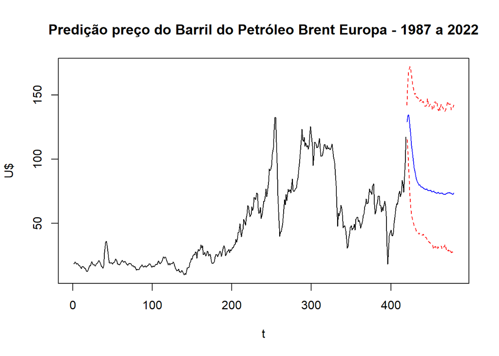

```r
#Predict TAR
set.seed(1)
pred = predict(modelo_final, n.ahead = 60, n.sim = 1000)
yy=ts(c(serie_petrol,pred$fit),frequency=1,start=1)
plot(yy,type='n',ylim=range(c(yy,pred$pred.interval)),
     ylab='U$',
     xlab=expression(t),
     main = 'Predição preço do Barril do Petróleo Brent Europa - 1987 a 2022')
lines(yy[1:419])
lines(window(yy, start=419+1),lty=1, col = 'blue')
lines(ts(pred$pred.interval[2,],start=419+1),lty=2, col = 'red')
lines(ts(pred$pred.interval[1,],start=419+1),lty=2, col = 'red')
```

Numéricamente, temos as seguintes predições:

```r
pred$fit
```

```
##    1-step    2-step    3-step    4-step    5-step    6-step    7-step    8-step
## 129.06005 133.66798 134.52887 130.92951 124.12709 118.12925 110.60218 103.77792
##    9-step   10-step   11-step   12-step   13-step   14-step   15-step   16-step
##  98.45901  93.36187  90.89533  87.46576  84.62567  82.90229  81.88664  79.77619
##   17-step   18-step   19-step   20-step   21-step   22-step   23-step   24-step
##  80.12344  79.26152  78.31590  78.20694  78.10430  77.48163  76.99476  76.47629
##   25-step   26-step   27-step   28-step   29-step   30-step   31-step   32-step
##  76.44247  76.75358  76.08312  75.49258  75.59455  75.35467  75.90873  74.57345
##   33-step   34-step   35-step   36-step   37-step   38-step   39-step   40-step
##  74.47556  74.85555  75.02822  74.14949  74.10583  73.54406  73.59506  73.90933
##   41-step   42-step   43-step   44-step   45-step   46-step   47-step   48-step
##  73.94019  73.23415  73.48781  73.54626  73.80792  73.16932  72.94228  72.44457
##   49-step   50-step   51-step   52-step   53-step   54-step   55-step   56-step
##  72.68437  72.86878  73.47944  73.66004  73.71571  73.69108  73.98125  73.48330
##   57-step   58-step   59-step   60-step
##  73.29249  72.93455  72.65517  73.70003
```

Com intervalos:

```r
pred$pred.interval
```

```
##         1-step   2-step    3-step    4-step    5-step    6-step    7-step
## 2.5%  115.2526 107.8661  96.62071  84.70077  71.22028  63.86204  56.26148
## 97.5% 142.2666 157.7391 166.93932 170.16051 172.08685 169.49748 165.40528
##          8-step    9-step   10-step   11-step   12-step   13-step   14-step
## 2.5%   52.61756  50.46063  48.36241  46.66407  46.05855  43.84209  42.79205
## 97.5% 158.28054 155.58088 152.57742 150.43661 151.44710 148.49732 148.20490
##         15-step   16-step   17-step   18-step   19-step   20-step   21-step
## 2.5%   42.92941  41.66458  42.38111  42.29344  41.40605  40.87694  41.09083
## 97.5% 148.02025 145.56663 144.63190 146.08680 146.31105 143.89299 144.76400
##         22-step   23-step   24-step   25-step   26-step   27-step   28-step
## 2.5%   41.67014  39.34481  39.47474  38.97236  38.05749  37.01019  37.22703
## 97.5% 145.05934 141.44844 141.39878 141.29911 142.80321 147.43922 142.80046
##         29-step   30-step   31-step   32-step   33-step   34-step   35-step
## 2.5%   35.60018  35.09596  34.24933  33.94298  33.54895  31.95865  29.74042
## 97.5% 140.91115 142.71044 143.09406 142.50352 138.45066 139.82901 140.12915
##         36-step   37-step   38-step   39-step   40-step   41-step   42-step
## 2.5%   31.48606  32.03159  29.87725  29.71064  31.68369  31.06952  31.21319
## 97.5% 144.54120 144.47705 142.69284 143.89795 138.95211 137.97124 140.77829
##         43-step   44-step   45-step   46-step   47-step   48-step   49-step
## 2.5%   31.83369  32.50178  30.43171  30.45283  31.83991  31.50227  33.44574
## 97.5% 138.10529 142.90155 142.01038 140.32236 138.96953 138.64365 137.21257
##         50-step   51-step   52-step   53-step   54-step   55-step   56-step
## 2.5%   31.86651  28.02514  28.74591  29.35947  28.37688  29.68949  28.86887
## 97.5% 138.33513 141.14481 145.13049 143.79678 142.85453 142.59914 142.74941
##         57-step   58-step   59-step   60-step
## 2.5%   27.12557  27.91053  26.88216  26.60572
## 97.5% 138.50282 139.43516 140.37017 142.18117
```

## Referências

Enders, W. (2008). Applied econometric time series. John Wiley & Sons.

J.B. Ramsey (1969), Tests for Specification Errors in Classical Linear Least-Squares Regression Analysis. Journal of the Royal Statistical Society, Series B 31, 350–371

W. Krämer & H. Sonnberger (1986), The Linear Regression Model under Test. Heidelberg: Physica